# Лабораторная работа № 9

## Задание по встроенному редактору mc

Создадим текстовой файл text.txt (рис. 30).

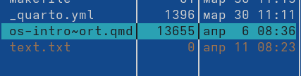

Figure 30: image30

## Задание по встроенному редактору mc

Откроем этот файл с помощью встроенного в mc редактора (рис. 31).

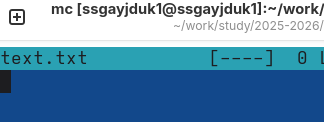

Figure 31: image31

## Задание по встроенному редактору mc

Вставим в открытый файл небольшой фрагмент текста, скопированный из Интернета (рис. 32).

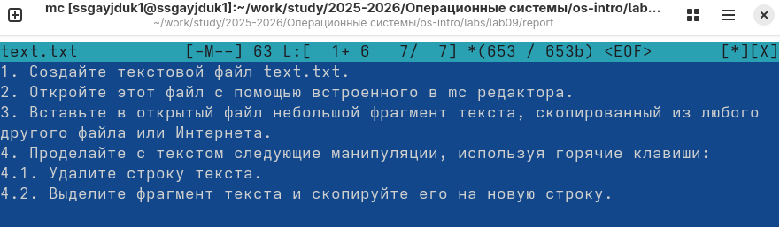

Figure 32: image32

## Задание по встроенному редактору mc

Проделаем с текстом следующие манипуляции, используя горячие клавиши: Удалим строку текста. Выделим фрагмент текста и скопируем его на новую строк. Выделим фрагмент текста и перенесем его на новую строку. Сохраним файл. Отменим последнее действие. Перейдем в конец файла (нажав комбинацию клавиш) и напишем некоторый текст. Перейдем в начало файла (нажав комбинацию клавиш) и напишем некоторый текст. Сохраним и закроем файл. И получим итоговый результат (рис. 33).

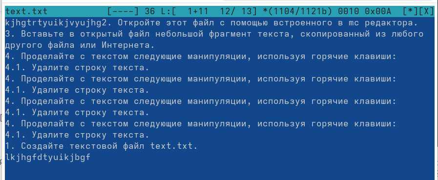

Figure 33: image33

## Работа с файлом

Откроем файл с исходным текстом на некотором языке программирования (например C или Java) (рис. 34).

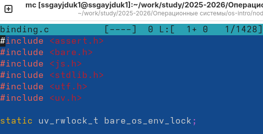

Figure 34: image34

## Работа с файлом

Используя меню редактора, включим подсветку синтаксиса, если она не включена, или выключим, если она включена (рис. 35).

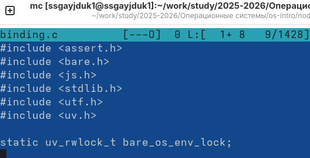

Figure 35: image35

## Список литературы

1.Kulyabov. Лабораторная работа № 9. Командная оболочка Midnight Commander. RUDN